# R Practical 6: General Linear Models

Alice Risely

## Learning outcomes for today

- Learn the difference between univariate and multivariate models
- Learn about the most common multivariate model: the General Linear Model (GLM)
- Recap: Load and explore the captive tiger dataset
- Recap: Conduct univariate models on tiger weight
- Conduct a generate linear model (GLM) on tiger weight
- Learn how to interpret the output of a GLM
- Learn how to present the output of a GLM
- Apply what you have learned by fitting a GLM to model penguin weight

## Preliminary tasks

1. **If you have not completed practicals 1 to 5, you need to do these first.**

2. If you are ready to start Practical 6, **DOWNLOAD the sixth practical worksheet** from Blackboard, do not just view it. To download it, click the “…” next to the file and click ‘Download original file’.

3. **Save this file in an appropriately named folder on your OneDrive** (e.g., “MODULE NAME/WEEK X”) so you can access it at home.

4. If you are using the cloud based version of R, **navigate on your web browser to [<https://login.rstudio.cloud/>](https://login.rstudio.cloud/)** andsign in. If prompted, click “Posit Cloud”. If you are using the desktop version of R, open your current project.

5. **You should already have an existing R studio project from the first practical called ‘R workshop’,** click on this to enter your saved workspace.

6. **Start a new R script for this practical.** Once your project has loaded (it takes a few seconds), click ‘File’ then ‘New file’, then ‘R Script’.

7. **Press the Save button and save your script as “Practical_6.R”.** This will save all your code you write today.

## Background: Univariate and multivariate models

So far, in this course you have largely been using UNIVARIATE models. Univariate models are those that looks at the **relationship between two variables** (e.g, when you are interested in knowing the impact of ONE variable on another variable).

**In contrast, MULTIVARIATE models are those that examine the effect of MULTIPLE variables on your variable of interest.**

All the statistical tests you have learned about so far have applied univariate models. T-tests, and one-way ANOVAs are all examples of test that fit simple, univariate models to your data.

However, it is very rare in nature that you have such simple data! In most cases, there are multiple sources of variation in your data, you usually you would want to capture that complexity using a multivariate model. You also may want to statistically control for any confounding variables in your study.

For example, you want to know the effect of parasite diversity on captive tiger weight. But weight might also be affected by age and sex, and the effect of these variables might obscure the real relationship between weight and parasite diversity.

You could fit four univariate models to look at the independent relationship between weight and parasite diversity, age, and sex. But this will give you biased results as these models can’t account for interactions in your data. It is also very clunky - why fit four models when you can just fit one?

A better way to do it would be to *control* for other variables, such as age and sex in your model, in order to get a more accurate estimate for the effect of parasites on weight. Therefore, you need a multivariate model!

## General Linear Models (GLMs)

General linear models are the most common multivariate models used in statistics. This is because they are extremely flexible - they can handle all sorts of data types and your data does not have to be normally distributed for you to use them (although there are other assumptions that we will get to later).

To fit a general linear model in R, you need the notation:

*m1 <- lm(response ~ explanatory1 + explanatory2 + explanatory3, data)*

This will fit a model that quantifies the effect of explanatory variables 1, 2 and 3 on your response variable. You need to save your model. In this case, I have saved it as an object called ‘m1’.

Next, lets use the tiger dataset to look at the impact of diet treatment on tiger weight, using the dataset tiger_weight.csv.

We will go through some of the basics first just as a recap.

## Q1) Examining predictors of tiger weight

**Goal: you want to know the effect of diet treatment on tiger weight, whilst controlling for all other variables that might influence weight.**

I will provide most of the R code you need to examine the predictors of tiger weight, including fitting and interpretting a GLM. Later, I will give you a new dataset and you will need to fit and interpret a GLM yourself.

## Install and load packages

First - we will need some new R packages. Lets install and load them. If you have already installed any in previous sessions, you don’t need to install them again.

```r
# install new packages. If you have already installed any of these before, you do not need to install them again.

install.packages("ggpubr") # package for presenting multiple plots
install.packages("sjPlot") # package for presenting GLMs
install.packages("broom") # package for tidying up model outputs
install.packages("palmerpenguins") # package containing an exmaple dataset
```

```r
# load packages into R environment

library(ggplot2)
library(ggpubr)
library(sjPlot)
library(broom)
library(palmerpenguins)
```

## Recap: Import and explore tiger dataset

In previous praticals (prac 3) you analysed the dataset on captive tigers.

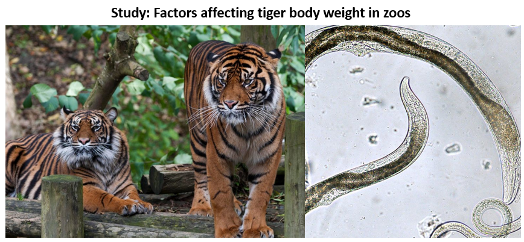

**This dataset includes data from a study that looked at the effect on antibiotic treatment and diet treatment on captive tiger weight and parasite load across zoos in the United States**. Parasite load was measured as the number of parasite eggs found in tiger faecal samples. The scientists also collected data on tiger age and sex.

#### Exercise 1

**Import the tiger data (tiger_data.csv) from this weeks Blackboard folder.**

```r
# import data

tiger_data <- read.csv("C:/Users/risel/Dropbox/Salford Research Fellowship/Teaching/2024-5/Data analysis - Content Creation in R/data/tiger_data.csv")# import tiger dataset and call the data 'tiger_data'
```

You should now how have tiger_data in your working environment. Lets go through the usual process of having a quick check of the dataset to make sure everything looks ok.

```r
head(tiger_data) # examine first 6 rows of dataset
```

|  | tiger_ID | weight_kg | parasite_load | antibiotic_treatment | diet_treatment | age_years | sex |
| --- | --- | --- | --- | --- | --- | --- | --- |
| 1 | 1 | 116.1 | 40 | With Antibiotics | High Fat | 2 | Female |
| 2 | 2 | 103.0 | 18 | With Antibiotics | High Protein | 5 | Female |
| 3 | 3 | 119.4 | 14 | With Antibiotics | High Fat | 8 | Male |
| 4 | 4 | 124.3 | 52 | With Antibiotics | High Protein | 5 | Female |
| 5 | 5 | 99.3 | 13 | With Antibiotics | High Fat | 2 | Female |
| 6 | 6 | 128.5 | 34 | With Antibiotics | High Fat | 8 | Male |

```r
str(tiger_data) # what data format are the variables in?
```

```
## 'data.frame':    110 obs. of  7 variables:
##  $ tiger_ID            : int  1 2 3 4 5 6 7 8 9 10 ...
##  $ weight_kg           : num  116.1 103 119.4 124.3 99.3 ...
##  $ parasite_load       : int  40 18 14 52 13 34 7 30 7 14 ...
##  $ antibiotic_treatment: chr  "With Antibiotics" "With Antibiotics" "With Antibiotics" "With Antibiotics" ...
##  $ diet_treatment      : chr  "High Fat" "High Protein" "High Fat" "High Protein" ...
##  $ age_years           : int  2 5 8 5 2 8 6 2 3 9 ...
##  $ sex                 : chr  "Female" "Female" "Male" "Female" ...
```

```r
dim(tiger_data) # What are the dimentions of the dataset? This tells you how many rows (110) and how many columns (7) there are
```

```
## [1] 110   7
```

```r
names(tiger_data) # what are the column names of the dataset? You will need to know these for your statistical analyses
```

```
## [1] "tiger_ID"             "weight_kg"            "parasite_load"
## [4] "antibiotic_treatment" "diet_treatment"       "age_years"
## [7] "sex"
```

## Summarize data

Lets summarise our key variables. Remember, to summarise numerical variables you need the function *summary()*, and to summarise categorical variables you need the function *table()*.

```r
# summarise numerical variables using summary() function

summary(tiger_data$weight_kg) # summary of tiger weight
```

```
##    Min. 1st Qu.  Median    Mean 3rd Qu.    Max.
##    90.7   104.3   113.9   114.0   122.1   142.5
```

```r
summary(tiger_data$parasite_load) # summary of parasite load
```

```
##    Min. 1st Qu.  Median    Mean 3rd Qu.    Max.
##     0.0    14.0    26.5    31.3    43.0   100.0
```

```r
# summarise categorical variables using table() function

table(tiger_data$antibiotic_treatment) # frequency of differnt antibiotic treatments
```

```
##
##   No Antibiotics With Antibiotics
##               55               55
```

```r
table(tiger_data$diet_treatment) # frequency of different diet treatments
```

```
##
##     High Fat High Protein
##           48           62
```

```r
table(tiger_data$sex) # requency of different tiger sexes
```

```
##
## Female   Male
##     46     64
```

## Plot your data

You want to know if diet treatment is significantly associated with tiger weight. But - weight could be influenced by loads of things! It could be affected by how many parasites a tiger has, it’s age, its sex, whether it had antibiotic treatment. Lets plot all the potential UNIVARIATE relationships with weight.

We will save all the plots as objects and then plot them together using the **ggarrange()** function.

```r
# Plot weight ~ antibiotic treatment

p1<-ggplot(tiger_data, aes(x = antibiotic_treatment, y = weight_kg))+
  geom_boxplot()

# Plot weight ~ diet treatment

p2<-ggplot(tiger_data, aes(x = diet_treatment, y = weight_kg))+
  geom_boxplot()

# Plot weight ~ sex

p3<-ggplot(tiger_data, aes(x = sex, y = weight_kg))+
  geom_boxplot()


# Plot weight ~ parasite load
p4<-ggplot(tiger_data, aes(x = parasite_load, y = weight_kg))+
  geom_point()+
  geom_smooth(method = "lm")

# Plot weight ~ age

p5<-ggplot(tiger_data, aes(x = age_years, y = weight_kg))+
  geom_point()+
  geom_smooth(method = "lm")
```

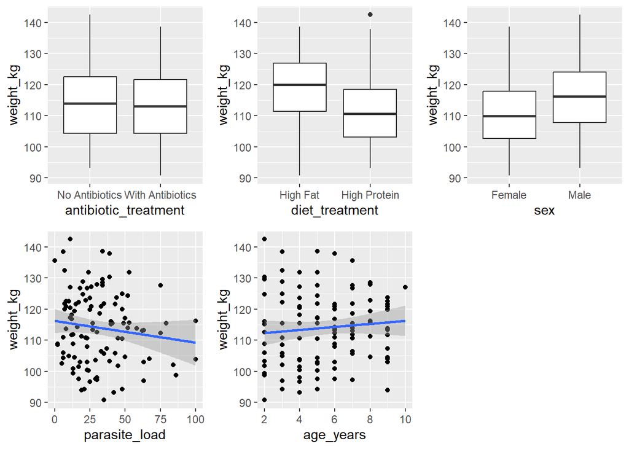

```r
## plot all together

ggarrange(p1, p2, p3, p4, p5) # ggarrange() is a function belonging to the ggpubr package we installed earlier
```

#### Exercise 2

Examine all the plots above. Which variables do you think have a significant association with weight, and what is the direction of the association for each one?

*ANSWER: From the plots, it looks like tigers fed high protein diets are lighter than those fed high fat diets, and males are heavier than females. There does seem to be a trend for tigers with more parasites to have fewer parasites too, although I am not sure if this would be statistically significant. There is not clear relationship between weight and antibiotic treatment and age, from looking at the plots.*

## Fitting univariate models

Above you have made five plots. That means we could conduct five univariate statistical tests to understand the effect of each variable on weight. Lets fit them seperately.

To choose the appropriate univariate statistical tests, you need to know if your numerical variables are normally disitrbuted or not.

Lets check if our three numerical variables are normally distributed:

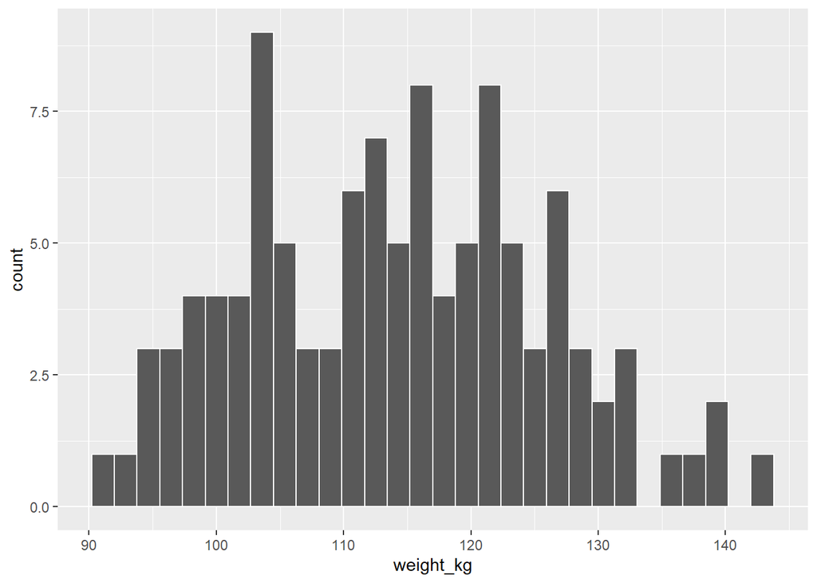

```r
#weight

ggplot(tiger_data, aes(x = weight_kg))+geom_histogram(col = "white")
```

```r
shapiro.test(tiger_data$weight_kg)
```

```
##
##  Shapiro-Wilk normality test
##
## data:  tiger_data$weight_kg
## W = 0.98521, p-value = 0.2667
```

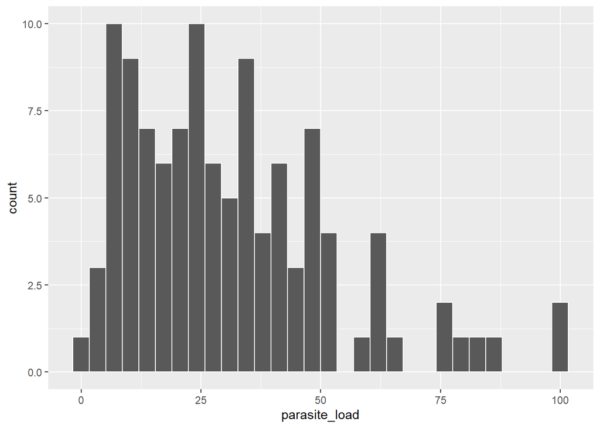

```r
# parasite load

ggplot(tiger_data, aes(x = parasite_load))+geom_histogram(col = "white")
```

```r
shapiro.test(tiger_data$parasite_load)
```

```
##
##  Shapiro-Wilk normality test
##
## data:  tiger_data$parasite_load
## W = 0.92318, p-value = 8.65e-06
```

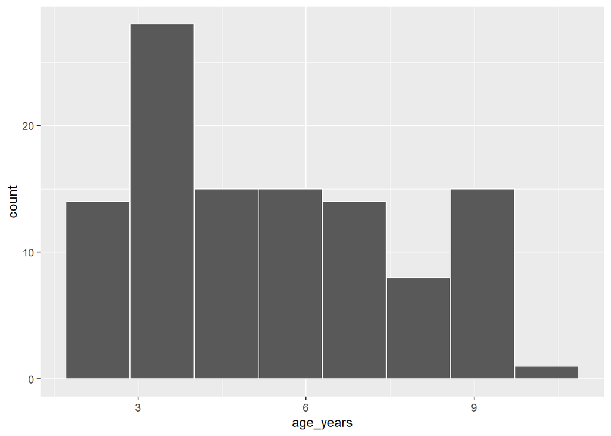

```r
# age

ggplot(tiger_data, aes(x = age_years))+geom_histogram(col = "white", bins =8 )
```

```r
shapiro.test(tiger_data$age_years)
```

```
##
##  Shapiro-Wilk normality test
##
## data:  tiger_data$age_years
## W = 0.93549, p-value = 4.657e-05
```

#### Exercise 3

Based on the shapiro wilk tests and histograms, are weight, parasite load, and age normally distributed or not?

ANSWER:

- **Weight = normally distributed**
- **Parasite load = NOT normally distributed**
- **Age = NOT normally distributed**

Lets next fit 5 univariate models to examine the effect of each variable on weight separately.

#### Exercise 4

Use the shapiro wilk tests and the framework below to decide which test you need for each univariate association:

**ANSWERS:**

*Weight ~ Antibiotic treatment; **Correct test = t-test***

*Weight ~ Diet treatment; **Correct test = t-test***

*Weight ~ Parasite load; **Correct test = Spearman’s correlation***

*Weight ~ Sex; **Correct test = t-test***

[figure not shown]

#### Exercise 5

Using the code cheatsheet as a reference, conduct the five univariate statistical tests you identified in exercise 4. Write your conclusions based on the results of the univariate test, making sure to include your statistical evidence in brackets.

1. Weight ~ Antibiotic treatment

```r
t.test(weight_kg~antibiotic_treatment, data = tiger_data)
```

```
##
##  Welch Two Sample t-test
##
## data:  weight_kg by antibiotic_treatment
## t = -0.014697, df = 107.99, p-value = 0.9883
## alternative hypothesis: true difference in means between group No Antibiotics and group With Antibiotics is not equal to 0
## 95 percent confidence interval:
##  -4.446526  4.381071
## sample estimates:
##   mean in group No Antibiotics mean in group With Antibiotics
##                       114.0255                       114.0582
```

*ANSWER: Antibiotic treatment has no significant effect on tiger weight (t test, t = -0.01, p = 0.98, n = 110).*

2. Weight ~ Diet treatment

```r
t.test(weight_kg~diet_treatment, data = tiger_data)
```

```
##
##  Welch Two Sample t-test
##
## data:  weight_kg by diet_treatment
## t = 2.8666, df = 95.675, p-value = 0.005103
## alternative hypothesis: true difference in means between group High Fat and group High Protein is not equal to 0
## 95 percent confidence interval:
##   1.931035 10.628240
## sample estimates:
##     mean in group High Fat mean in group High Protein
##                   117.5812                   111.3016
```

*ANSWER: A high fat diet significantly increases tiger weight (t test, t = 2.9, p = 0.005, n = 110).*

3. Weight ~ Age

```r
cor.test(tiger_data$age_years,tiger_data$weight_kg, method = "spearman")
```

```
##
##  Spearman's rank correlation rho
##
## data:  tiger_data$age_years and tiger_data$weight_kg
## S = 195033, p-value = 0.2089
## alternative hypothesis: true rho is not equal to 0
## sample estimates:
##       rho
## 0.1207422
```

*ANSWER:There is no correlation between age and tiger weight (Spearman’s correlation; S = 195033, p = 0.21, n = 110).*

4. Weight ~ Parasite load

```r
cor.test(tiger_data$parasite_load,tiger_data$weight_kg, method = "spearman")
```

```
##
##  Spearman's rank correlation rho
##
## data:  tiger_data$parasite_load and tiger_data$weight_kg
## S = 243195, p-value = 0.3165
## alternative hypothesis: true rho is not equal to 0
## sample estimates:
##         rho
## -0.09638454
```

*ANSWER:There is no correlation between parasite load and weight (Spearman’s corretaion, S = 243195, p = 0.32, n = 110).*

5. Weight ~ Sex

```r
t.test(weight_kg~sex, data = tiger_data)
```

```
##
##  Welch Two Sample t-test
##
## data:  weight_kg by sex
## t = -2.5455, df = 101.16, p-value = 0.01242
## alternative hypothesis: true difference in means between group Female and group Male is not equal to 0
## 95 percent confidence interval:
##  -9.814248 -1.217409
## sample estimates:
## mean in group Female   mean in group Male
##             110.8326             116.3484
```

*ANSWER:Male tigers are significantly heavier than female tigers (t test, t = -2.5, p = 0.01, n = 110).*

#### Exercise 6

Out of the five variables tested above, which had significant effects on weight, and which didn’t?

*ANSWER: Diet treatment and sex are significantly associated with weight.*

## Fitting a GLM

We have now looked at the relationship between weight and the five explanatory variables by plotting their relationships and fitting five univariate models.

However, this was a very long-winded approach! Lets now just fit one MULTIVARIATE general linear model with all variables in one model. We can then compare the results to our univariate models.

```r
weight_model <- lm(weight_kg ~
                     antibiotic_treatment +
                     diet_treatment+
                     sex+
                     parasite_load +
                     age_years,
                   data = tiger_data)

summary(weight_model)
```

```
##
## Call:
## lm(formula = weight_kg ~ antibiotic_treatment + diet_treatment +
##     sex + parasite_load + age_years, data = tiger_data)
##
## Residuals:
##      Min       1Q   Median       3Q      Max
## -27.7883  -7.7768  -0.1197   6.4391  29.3017
##
## Coefficients:
##                                       Estimate Std. Error t value Pr(>|t|)
## (Intercept)                          115.07407    4.21516  27.300  < 2e-16 ***
## antibiotic_treatmentWith Antibiotics  -0.53547    2.27483  -0.235  0.81437
## diet_treatmentHigh Protein            -5.88505    2.21261  -2.660  0.00906 **
## sexMale                                3.86133    2.26597   1.704  0.09136 .
## parasite_load                         -0.07171    0.05163  -1.389  0.16783
## age_years                              0.46838    0.46656   1.004  0.31776
## ---
## Signif. codes:  0 '***' 0.001 '**' 0.01 '*' 0.05 '.' 0.1 ' ' 1
##
## Residual standard error: 11.08 on 104 degrees of freedom
## Multiple R-squared:  0.1328, Adjusted R-squared:  0.09106
## F-statistic: 3.184 on 5 and 104 DF,  p-value: 0.01026
```

## Interpreting a GLM output

There is a lot of break down in the output of a GLM. Below we will go through the output step by step.

### The intercept and reference groups

The first thing to look at is the first row of the Estimate column. This represents the INTERCEPT of your reference group (see below for explanation for what a reference group is). If you have no categorical variables in your model, this number will roughly represent the overall average of your response variable (in this case, the response variable is weight).

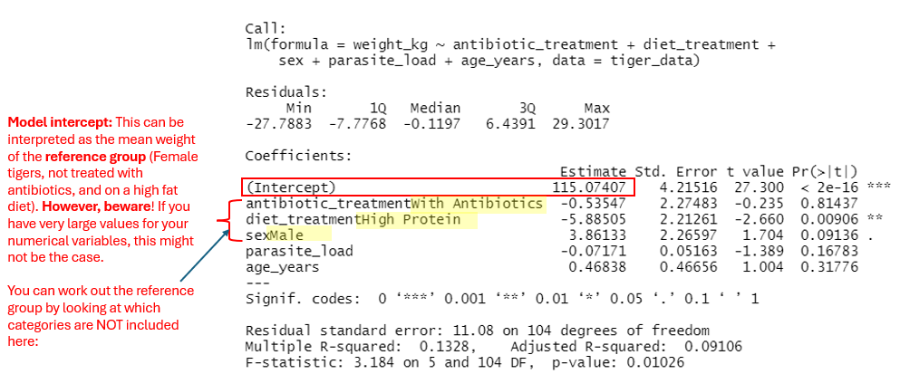

If you DO have numerical variables in your model (we do - age and parasite load), the intercept represents the estimated mean response when all predictor variables are set to zero.

However, if your numerical variables are really large and not close to zero (e.g., blackbird weight in your assignment data), you might get a weird intercept value. This isn’t so important, it just means that number will be difficult to interpret.

**Reference group**: If you have categorical variables in your model, the model will automatically pick a reference group. In this case, the reference group of tigers is female, was not given atibiotics, and were fed a high fat diet.

Unless you reorder the levels manually, R automatically puts categorical levels in alphabetical order (e.g, female is before male when ordered alphabetically).

### Estimates

Estimates tell you the relationship between each explanatory variable and your response variable (in this case weight), in relation to the reference group. Below is a breakdown of what each estimate value means. Check out the p value to work out if the relationship is significant, and make sure you note whether the relationship is positive or negative.

[figure not shown]

### Effect sizes - which variable has the strongest effect?

Which variables have the strongest and weakest effect on tiger weight? Look at the effect size!

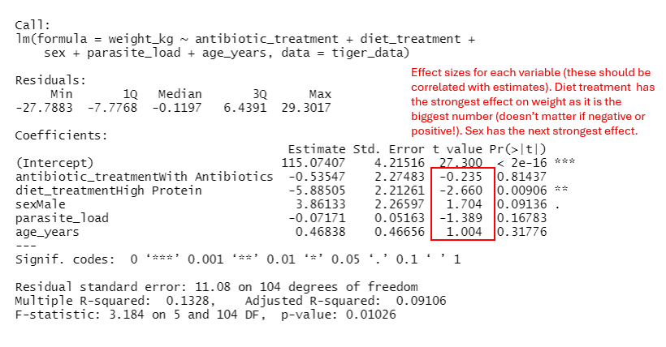

### Standard errors (a measure of confidence in the estimate)

For which variable do we have the most confidence about the true estimate? Look at the standard error (or 95% confidence interval). Both standard errors and confidence intervals tell us something about the error around the estimate.

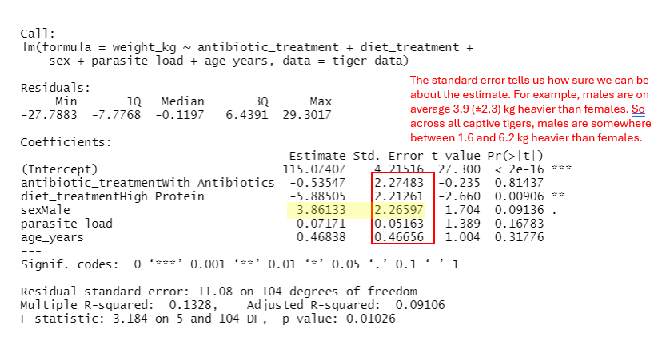

### Model fit

How good is our model at explaining tiger weight? The adjusted R2 tell your how well the model fits your data. In this case, the R2 is 0.09 - our explanatory variables in the model together account for 9% of the variation in tiger weight.

Given our R2 is quite low, there are probably other important variables out there that we havent measuresd and which are more important for explaining tiger weight than the variables we have included in our model.

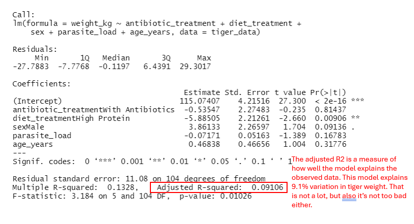

### Model assumptions

The most important assumption of GLMs is that the RESIDUALS of the model are more or less normally distributed. Model residuals are the differences between the actual observed values and the predicted values in a statistical model.

In the figure below, the observed values are represented by the points, and the predicted values sit along the model regression line. Therefore, the residuals are the difference between the observed value and the predicted value:

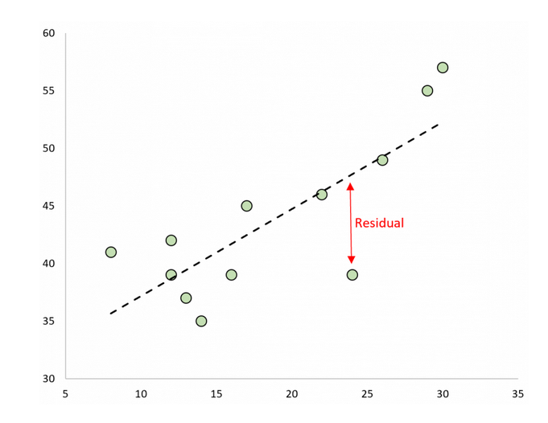

I would normally recommend that you always use ggplot2 to plot your data. The one exception is if you want to quickly plot a histogram from a list of numbers. In this case, use the base function hist() - it is much simpler!

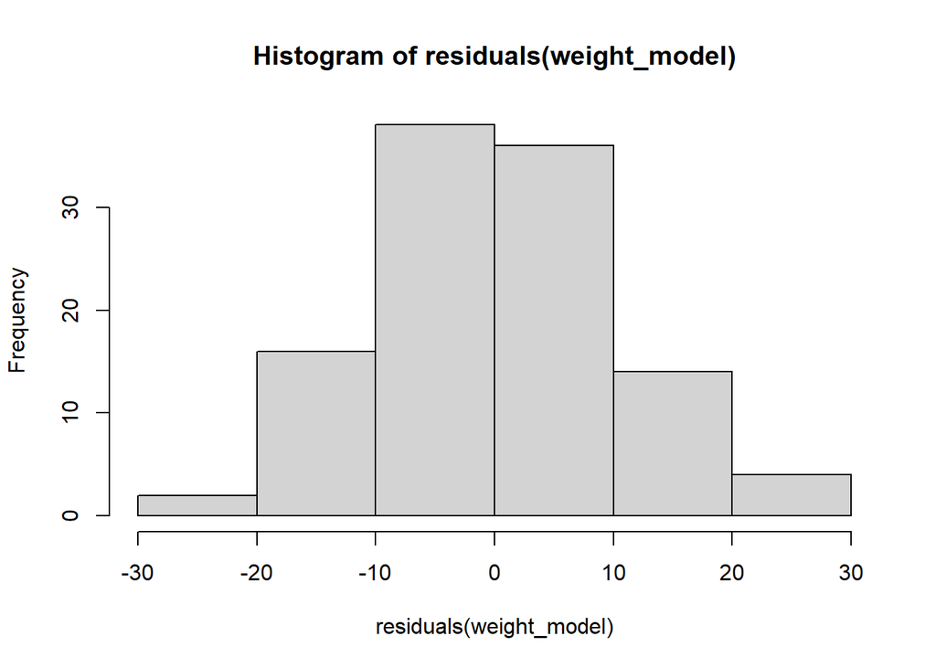

```r
hist(residuals(weight_model))
```

The residuals are normally distributed, so the main model assumption has been met. We can proceed to presenting the results of our model. If the residuals had been skewed, we would need to think about fitting a more complex model or transforming our data. We will not go into these problems here, but you may need to consider such problems when you are analysing your own data (e.g., for your thesis).

### Presenting GLM results as a table

Presenting model results can be tricky. There are two packages that help you tidy up the model output into a presentable format. Note that when presenting measures of confidence, you can either present the standard error OR 95% confidence interval. Both are acceptable.

```r
# Use the tidy() function to extract the table
broom::tidy(weight_model)
```

| term | estimate | std.error | statistic | p.value |
| --- | --- | --- | --- | --- |
| (Intercept) | 115.07406603 | 4.21516398 | 27.3000212 | 3.125829e-49 |
| antibiotic_treatmentWith Antibiotics | -0.53547444 | 2.27482773 | -0.2353912 | 8.143680e-01 |
| diet_treatmentHigh Protein | -5.88505253 | 2.21261038 | -2.6597781 | 9.057035e-03 |
| sexMale | 3.86133199 | 2.26596573 | 1.7040558 | 9.135678e-02 |
| parasite_load | -0.07171247 | 0.05163208 | -1.3889130 | 1.678263e-01 |
| age_years | 0.46837707 | 0.46656486 | 1.0038842 | 3.177645e-01 |

```r
# You can save this table to your working directory as an excel file

table<-tidy(weight_model) # save table as an R object
#write.csv(table, "weight_model_table.csv") # save file

# OR zou can use the tab_model() function in the R package sjPlot.
# This function is great!

sjPlot::tab_model(weight_model)
```

|  | weight_kg |  |  |
| --- | --- | --- | --- |
| Predictors | Estimates | CI | p |
| (Intercept) | 115.07 | 106.72 – 123.43 | **<0.001** |
| antibiotic treatment [With Antibiotics] | -0.54 | -5.05 – 3.98 | 0.814 |
| diet treatment [High Protein] | -5.89 | -10.27 – -1.50 | **0.009** |
| sex [Male] | 3.86 | -0.63 – 8.35 | 0.091 |
| parasite load | -0.07 | -0.17 – 0.03 | 0.168 |
| age years | 0.47 | -0.46 – 1.39 | 0.318 |
| Observations | 110 |  |  |
| R<sup>2</sup> / R<sup>2</sup> adjusted | 0.133 / 0.091 |  |  |

```r
tab_model(weight_model, show.se = T, show.stat = T) # Include standard error and effect size  in output
```

|  | weight_kg |  |  |  |  |
| --- | --- | --- | --- | --- | --- |
| Predictors | Estimates | std. Error | CI | Statistic | p |
| (Intercept) | 115.07 | 4.22 | 106.72 – 123.43 | 27.30 | **<0.001** |
| antibiotic treatment [With Antibiotics] | -0.54 | 2.27 | -5.05 – 3.98 | -0.24 | 0.814 |
| diet treatment [High Protein] | -5.89 | 2.21 | -10.27 – -1.50 | -2.66 | **0.009** |
| sex [Male] | 3.86 | 2.27 | -0.63 – 8.35 | 1.70 | 0.091 |
| parasite load | -0.07 | 0.05 | -0.17 – 0.03 | -1.39 | 0.168 |
| age years | 0.47 | 0.47 | -0.46 – 1.39 | 1.00 | 0.318 |
| Observations | 110 |  |  |  |  |
| R<sup>2</sup> / R<sup>2</sup> adjusted | 0.133 / 0.091 |  |  |  |  |

### Presenting model results as a figure

It’s often good to present your model estimates as a figure because figures are always easier to digest than tables. You can use the function plot_model() in the package sjPlot to plot your model estimates and confidence intervals.

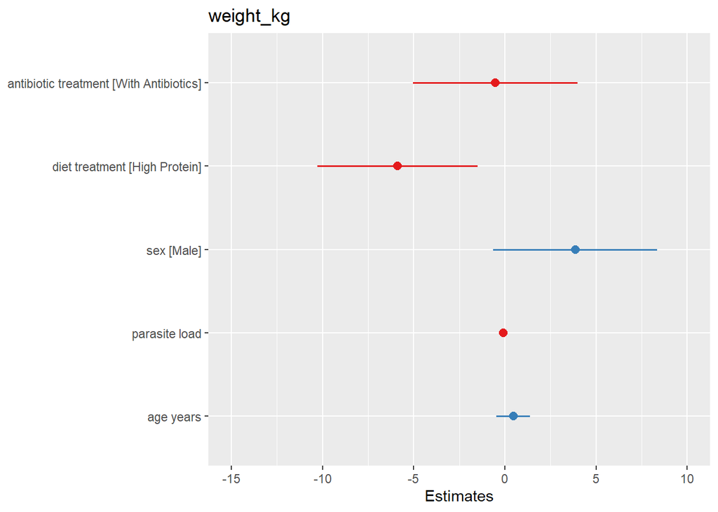

```r
sjPlot::plot_model(weight_model)
```

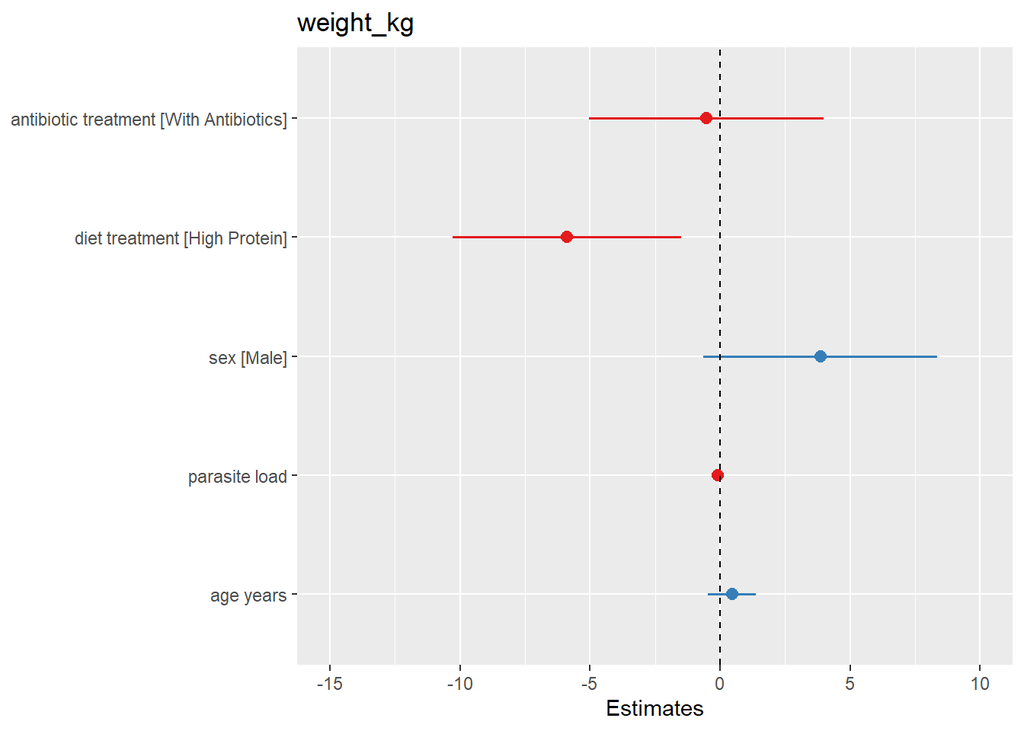

```r
# Add a line around zero. If the confidence intervals overlap zero, you know that variable is not a significant predictor of weight

sjPlot::plot_model(weight_model)+
  geom_hline(yintercept = 0, linetype = "dashed") # add  line
```

#### Exercise 7

How do the results from the GLM compare to those of your univariate tests? Are there any associations that differ in their significance?

*ANSWER: Overall the conclusions are quite similar. The only difference is that when conducting univariate analyses, sex was a significant predictor of weight, but this was not the case in the GLM. This is because sex becomes less important when accounting for other variables such as diet treatment.*

### Writing conclusions based on GLMs

How would you write your conclusions? Remember, you are mainly interested in the effect of diet treatment so you should focus on this. Here is an example of how you could write out your results:

*“The weight of captive tigers was significantly associated with diet treatment, with tigers fed a high protein diet on average 5.9kg lighter than those fed a high fat diet (GLM, t = -2.7, p = 0.009). Antibiotic treatment had no impact on weight (GLM; t = -0.2, p = 0.81), nor did parasite load (GLM; t = -1.4, p = 0.17) and age (GLM; t = 1.0, p = 0.32). Males had a tendency to be heavier than females (GLM; t = 1.7, p = 0.09) but this association was not significant. The model explained over 9.1% of the variation in tiger weight (adjusted R2 = 0.091).”*

## Q2) Examining the predictors of penguin weight

Now it is your turn to explore the drivers of weight - but this time in penguins! You want to identify the strongest predictors of weight in three species of penguins in Antarctica.

Lets use an example dataset available from the R package palmerpenguins.

```r
data(penguins) # load example dataset

head(penguins) # check out dataset
```

| species | island | bill_length_mm | bill_depth_mm | flipper_length_mm | body_mass_g | sex | year |
| --- | --- | --- | --- | --- | --- | --- | --- |
| Adelie | Torgersen | 39.1 | 18.7 | 181 | 3750 | male | 2007 |
| Adelie | Torgersen | 39.5 | 17.4 | 186 | 3800 | female | 2007 |
| Adelie | Torgersen | 40.3 | 18.0 | 195 | 3250 | female | 2007 |
| Adelie | Torgersen | NA | NA | NA | NA | NA | 2007 |
| Adelie | Torgersen | 36.7 | 19.3 | 193 | 3450 | female | 2007 |
| Adelie | Torgersen | 39.3 | 20.6 | 190 | 3650 | male | 2007 |

```r
dim(penguins) # dataset consists of 344 penguins and 8 columns
```

```
## [1] 344   8
```

```r
names(penguins) # column names
```

```
## [1] "species"           "island"            "bill_length_mm"
## [4] "bill_depth_mm"     "flipper_length_mm" "body_mass_g"
## [7] "sex"               "year"
```

```r
str(penguins) # all looks ok apart from the varible year, which should be categorical, not numeric
```

```
## tibble [344 x 8] (S3: tbl_df/tbl/data.frame)
##  $ species          : Factor w/ 3 levels "Adelie","Chinstrap",..: 1 1 1 1 1 1 1 1 1 1 ...
##  $ island           : Factor w/ 3 levels "Biscoe","Dream",..: 3 3 3 3 3 3 3 3 3 3 ...
##  $ bill_length_mm   : num [1:344] 39.1 39.5 40.3 NA 36.7 39.3 38.9 39.2 34.1 42 ...
##  $ bill_depth_mm    : num [1:344] 18.7 17.4 18 NA 19.3 20.6 17.8 19.6 18.1 20.2 ...
##  $ flipper_length_mm: int [1:344] 181 186 195 NA 193 190 181 195 193 190 ...
##  $ body_mass_g      : int [1:344] 3750 3800 3250 NA 3450 3650 3625 4675 3475 4250 ...
##  $ sex              : Factor w/ 2 levels "female","male": 2 1 1 NA 1 2 1 2 NA NA ...
##  $ year             : int [1:344] 2007 2007 2007 2007 2007 2007 2007 2007 2007 2007 ...
```

```r
penguins$year<-factor(penguins$year) # convert year into a categorical variable
```

Lets also remove any rows with missing values using the **na.omit()** function. This function romoves all rows with missing data at all.

```r
penguins <- na.omit(penguins)
```

#### Exercise 8

Plot the relationship between penguin weight (body_mass_g) and a) species, b) flipper_length, c) bill length, and d) sex. Present the plots together using the ggarrange() function. Copy your composite plot below.

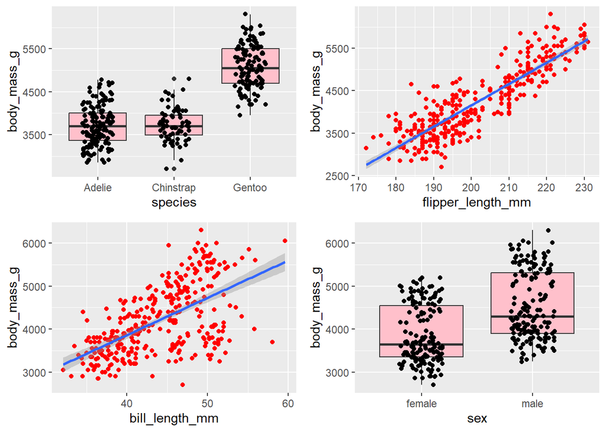

```r
# weight ~ species
p1<-ggplot(penguins, aes(x = species, y = body_mass_g))+
  geom_boxplot(fill = "pink")+
  geom_jitter(width = 0.2)

# weight ~ flipper length
p2<-ggplot(penguins, aes(x = flipper_length_mm, y = body_mass_g))+
  geom_point(col = "red")+
  geom_smooth(method = lm)

# weight ~ bill length
p3<-ggplot(penguins, aes(x = bill_length_mm, y = body_mass_g))+
  geom_point(col = "red")+
  geom_smooth(method = lm)

# weight ~ sex
p4<- ggplot(penguins, aes(x = sex, y = body_mass_g))+
  geom_boxplot(fill = "pink")+
  geom_jitter(width = 0.2)

# composite plot
ggarrange(p1, p2, p3, p4)
```

#### Exercise 9

Which variables look like they would be significantly associated with weight?

**ANSWER: All variables look like they are significantly associated with weight.**

#### Exercise 10

Fit a GLM that examines the effects of flipper length, bill length, species, and sex on penguin body mass.

```r
penguin_model <- lm(body_mass_g ~ flipper_length_mm+
                      bill_length_mm+
                      species +
                      sex,
                    data = penguins)

summary(penguin_model)
```

```
##
## Call:
## lm(formula = body_mass_g ~ flipper_length_mm + bill_length_mm +
##     species + sex, data = penguins)
##
## Residuals:
##     Min      1Q  Median      3Q     Max
## -718.50 -201.60  -12.75  198.45  878.24
##
## Coefficients:
##                   Estimate Std. Error t value Pr(>|t|)
## (Intercept)       -759.064    541.377  -1.402 0.161834
## flipper_length_mm   17.847      2.902   6.150 2.25e-09 ***
## bill_length_mm      21.633      7.148   3.027 0.002670 **
## speciesChinstrap  -291.711     81.502  -3.579 0.000397 ***
## speciesGentoo      707.028     94.359   7.493 6.35e-13 ***
## sexmale            465.395     43.081  10.803  < 2e-16 ***
## ---
## Signif. codes:  0 '***' 0.001 '**' 0.01 '*' 0.05 '.' 0.1 ' ' 1
##
## Residual standard error: 292 on 327 degrees of freedom
## Multiple R-squared:  0.8705, Adjusted R-squared:  0.8685
## F-statistic: 439.7 on 5 and 327 DF,  p-value: < 2.2e-16
```

#### Exercise 11

Are the residuals to the model normally distributed? Present the histogram below.

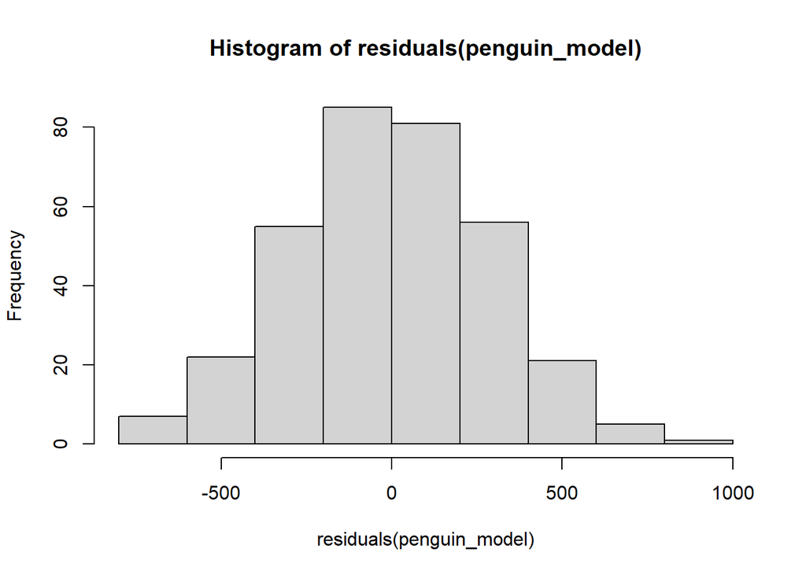

```r
hist(residuals(penguin_model))
```

*ANSWER: Yes, they are normally distributed. Model is therefore appropriate.*

#### Exercise 12

Present a table of your model, including the standard errors and the effect size (effect size in GLMs = t value).

```r
# Need R package sjPlot loaded

sjPlot::tab_model(penguin_model, show.stat = T, show.se = T)
```

|  | body_mass_g |  |  |  |  |
| --- | --- | --- | --- | --- | --- |
| Predictors | Estimates | std. Error | CI | Statistic | p |
| (Intercept) | -759.06 | 541.38 | -1824.08 – 305.96 | -1.40 | 0.162 |
| flipper length mm | 17.85 | 2.90 | 12.14 – 23.55 | 6.15 | **<0.001** |
| bill length mm | 21.63 | 7.15 | 7.57 – 35.69 | 3.03 | **0.003** |
| species [Chinstrap] | -291.71 | 81.50 | -452.04 – -131.38 | -3.58 | **<0.001** |
| species [Gentoo] | 707.03 | 94.36 | 521.40 – 892.66 | 7.49 | **<0.001** |
| sex [male] | 465.40 | 43.08 | 380.64 – 550.15 | 10.80 | **<0.001** |
| Observations | 333 |  |  |  |  |
| R<sup>2</sup> / R<sup>2</sup> adjusted | 0.871 / 0.869 |  |  |  |  |

#### Exercise 13

Present a plot of your model estimates, using the function *plot_model() .*

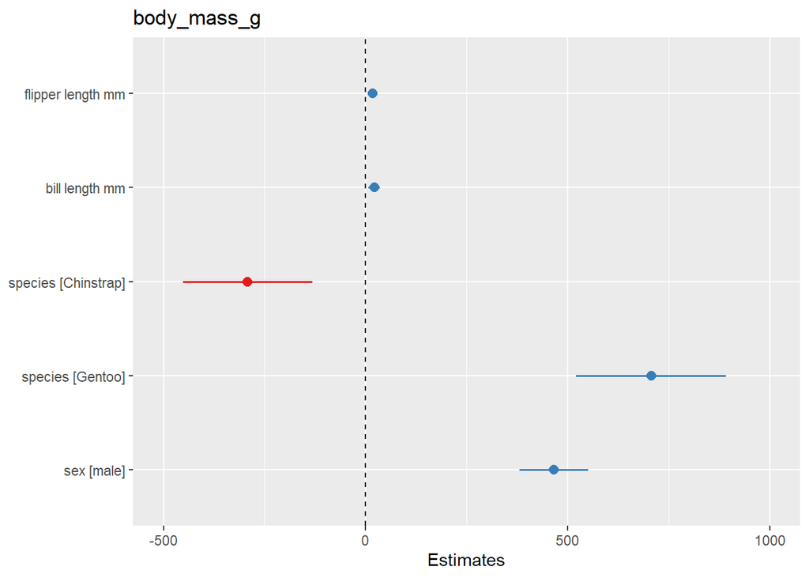

```r
sjPlot::plot_model(penguin_model)+geom_hline(yintercept = 0, linetype = "dashed")
```

#### Exercise 14

Write out your results of your model, embedding statistical support from your model into your sentences. What are the strongest and weakers predictors of penguin weight? Which variables did not significantly predict weight? How much variation in penguin weight is explained by the model?

*ANSWER: Penguin weight is largely determined by species (Adelie vs Chinstrap: GLM, t = -3.58, p < 0.001; Adelie vs Gentoo: GLM, t = 7.49, p < 0.001) and sex (female vs male: GLM, t = 10.8, p < 0.001), with male and Gentoo penguins being heavier than female and Adelie individuals. Flipper length is a better indicator of weight than bill length, with both significantly predicting weight (flipper length: GLM, t = 6.15, p < 0.001; Bill length: GLM, t = 3.0, p = 0.003). Overall, penguin sex is the strongest significant predictors of weight, and bill length is the weakest predictor of weight. The model had an adjusted R2 of 0.87, suggesting species identity, sex, and body size measures together explain almost 90% of variation in penguin body weight.*